# ECSS 2024: Relative fat mass is not associated with muscle adaptations to resistance training

Author

Hamarsland, Hammarström

## Participants

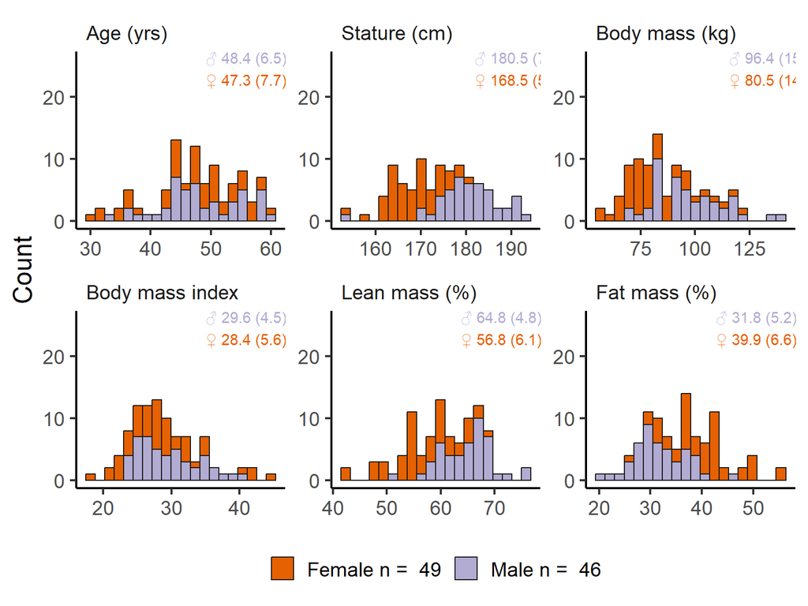

Figure 1: Participants included in per protocol analysis (completed *T4*). Bars in the histogram are stacked.

Table 1: Characteristics of participants completing T4. Data are presented as Mean (SD).

| Sex | Placebo Age | Placebo BMI | Placebo n | Omega-3 Age | Omega-3 BMI | Omega-3 n |
| --- | --- | --- | --- | --- | --- | --- |
| Male | 49.3 (6.1) | 29.9 (5.4) | 23 | 47.4 (6.9) | 29.3 (3.4) | 23 |
| Female | 48.6 (8.2) | 27.8 (4.5) | 21 | 46.3 (7.4) | 28.9 (6.4) | 28 |

Table 2: Characteristics of participants completing T4. Data are presented as Mean (SD).

| Sex | Age | BMI | n |
| --- | --- | --- | --- |
| Male | 48.4 (6.5) | 29.6 (4.5) | 46 |
| Female | 47.3 (7.7) | 28.4 (5.6) | 49 |

## Training conditions and outcome agreement

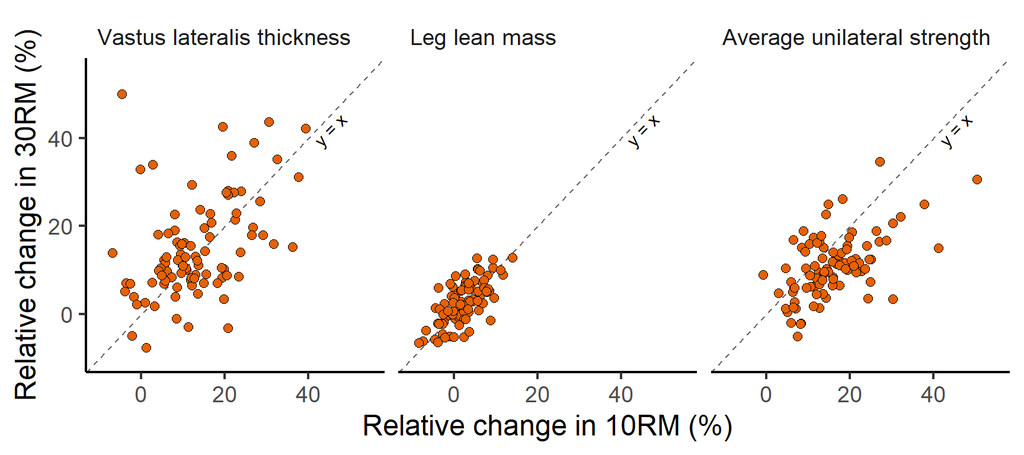

Figure 2: Association between training-induced relative changes in response to 10RM and 30RM training conditions. Leg lean mass, r = 0.71, 95% CI: [0.59, 0.8]; Average unilateral strength, r = 0.55, 95% CI: [0.39, 0.68]; Vastus lateralis thickness, r = 0.44, 95% CI: [0.26, 0.59].

### Effects of baseline relative fat mass and training condition on Vastus lateralis thickness

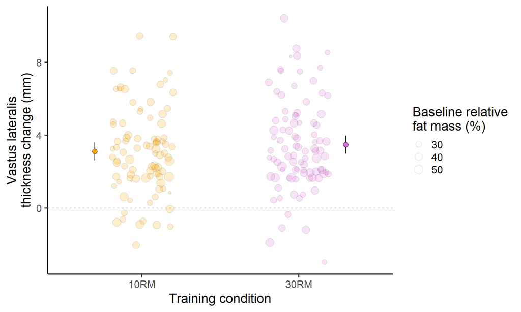

Figure 3: Differences between training conditions in training-induced vastus lateralis thickness (mm). Mean difference 30RM vs. 10RM: 0.39 mm, 95% CI: [-0.14, 0.91], p = 0.149. Accounting for baseline VL thickness and sex.

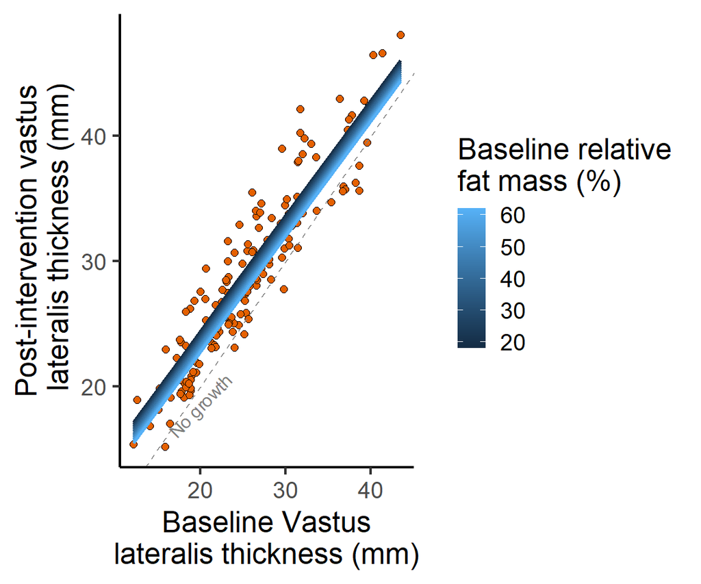

Figure 4: Association between baseline relative fat mass and vastus lateralis thickness change. For every %-point increase in baseline relative fat mass, VL thickness was estimated to be reduced by -0.038 mm. 95% CI: [-0.105, 0.03], p = 0.282.. Estimates are conditional on sex and baseline VL thickness. Duplicate observations (training conditions) from participants are accounted for in a mixed effects model.

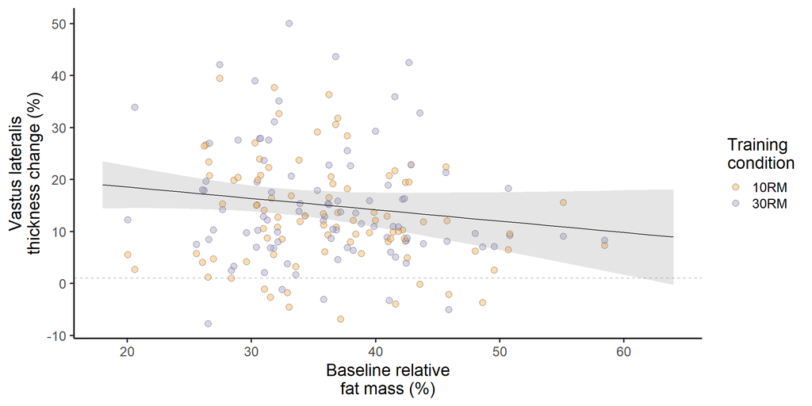

Figure 5: Association between baseline relative fat mass and vastus lateralis thickness change. For every %-point increase in baseline relative fat mass, training-induced change in VL thickness was estimated to be reduced by Average : -0.22 mm, 95% CI: [-0.49, 0.05], p = 0.124. Each participants contributes duplicate measures to the model (training conditions), these are accounted for in a mixed-effects model that also accounts for sex and baseline VL thickness.

## Leg lean mass (DXA)

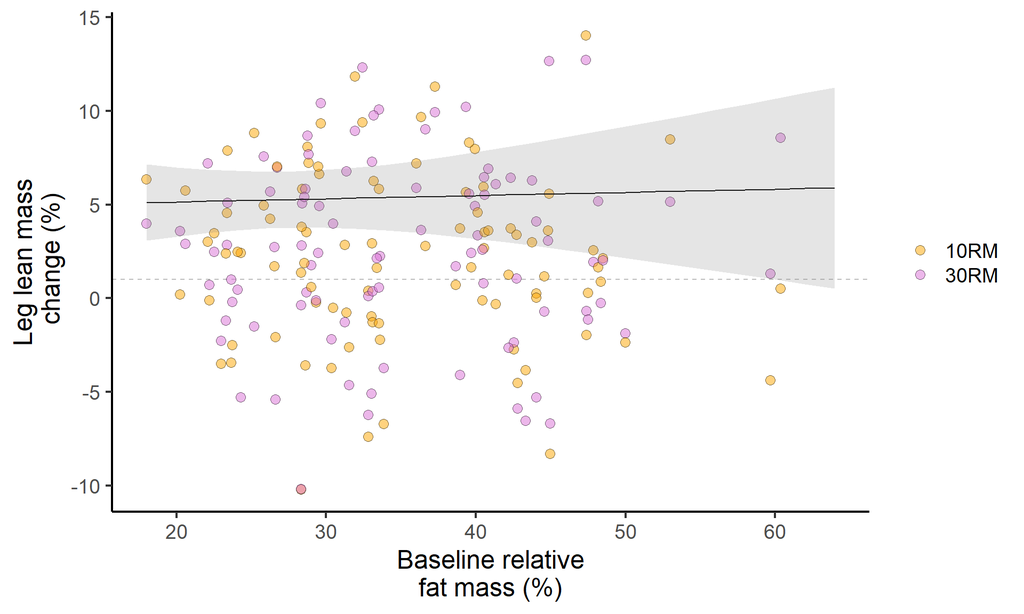

Figure 6: Association between baseline relative fat mass and leg lean mass change. For every %-point increase in baseline relative fat mass, training-induced change leg lean mass was estimated to be affected by Average : 0.02 mm, 95% CI: [-0.12, 0.16], p = 0.815. Each participants contributes duplicate measures to the model (training conditions), these are accounted for in a mixed-effects model that also accounts for sex and baseline lean mass.

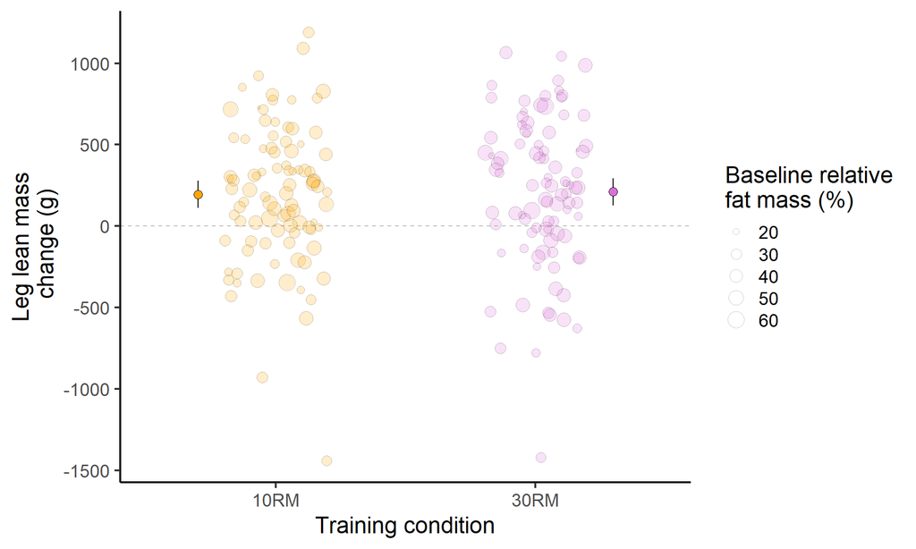

Figure 7: Average difference between training conditions in leg lean mass: Mean difference 30RM vs. 10RM: 17.8 g, 95% CI: [-48.88, 84.43], p = 0.6

## Strength

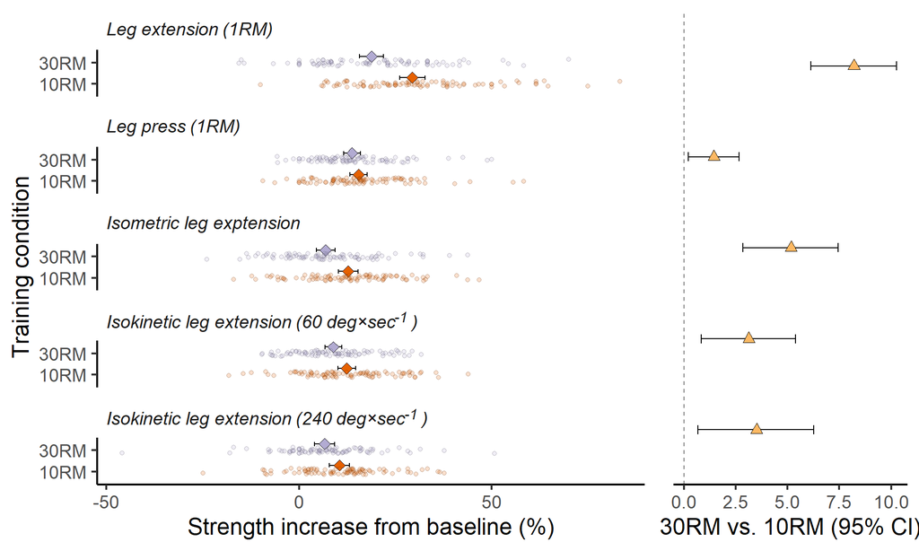

Figure 8: Average difference between training conditions in unilateral strength. Overall benefit of the 10RM condition. Paired comparisons between conditions in change scores after controlling for baseline values and sex.

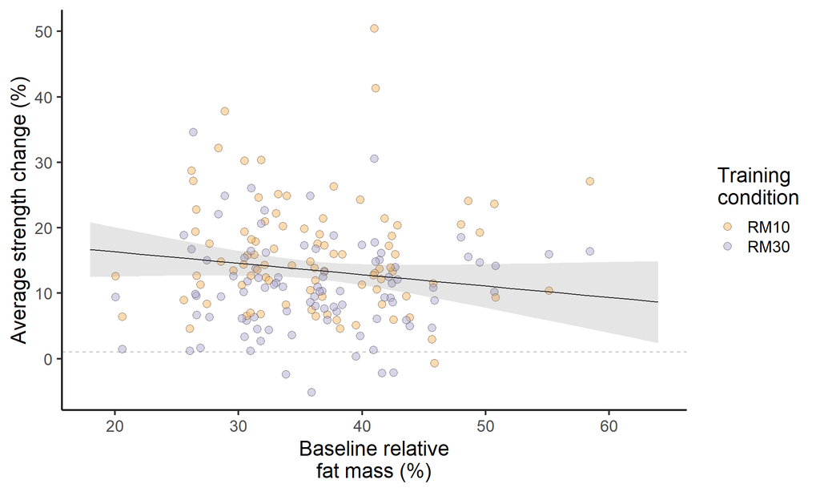

Figure 9: Association between baseline relative fat mass and average leg strength change. For every %-point increase in baseline relative fat mass, training-induced change average leg strength was estimated to be affected by Average : -0.17 mm, 95% CI: [-0.39, 0.04], p = 0.123. Each participants contributes duplicate measures to the model (training conditions), these are accounted for in a mixed-effects model that also accounts for sex and baseline average strength.

## Sex interactions

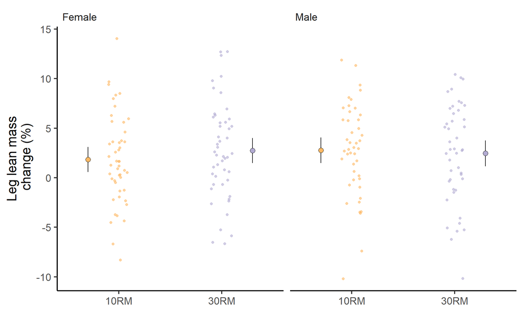

Figure 10: There were no differences between males and females in leg lean mass changes (%) (p = 0.726). Males and females showed similar changes in lean mass across training conditions (p = 0.153) and baseline relative fat mass (p = 0.929)

Male gain in leg lean mass was 2.6%, [1.4, 3.8] and in females 2.3%, [1.1, 3.4]. The average estimated difference between males and females was 0.3%-points, [-1.4, 2]. The average difference between conditions was -0.2%-point, [-1.2, 0.8] in male and 0.8%-point, [-0.2, 1.7] in females. The differences between sexes condition-differences was estimated to -1%-points, [-2.4, 0.4]. For every percentage-point increase in baseline fat mass, males were estimated to have a 0%-point, [-0.2, 0.3] and females 0%-point, [-0.2, 0.2] difference in leg lean mass training induced change. Difference between sexes was estimated to 0%-points, [-0.3, 0.3].

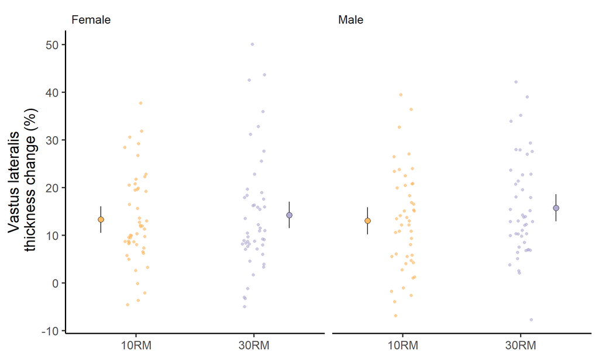

Figure 11: There were no differences between males and females in vastus lateralis thickness changes (%) (p = 0.675). Males and females showed similar changes in VL thickness across training conditions (p = 0.485) and baseline relative fat mass (p = 0.719)

Male gain in vastus lateralis thickness was 14.4%, [12, 16.8] and in females 13.8%, [11.4, 16.1]. The average estimated difference between males and females was 0.7%-points, [-2.6, 4.1]. The average difference between conditions was 2.7%-point, [-0.3, 5.8] in male and 1.2%-point, [-1.8, 4.2] in females. The differences between sexes condition-differences was estimated to 1.5%-points, [-2.7, 5.8]. For every percentage-point increase in baseline fat mass, males were estimated to have a -0.1%-point, [-0.6, 0.3] and females -0.3%-point, [-0.6, 0.1] difference in vastus lateralis thickness training induced change. Difference between sexes was estimated to 0.1%-points, [-0.5, 0.7].

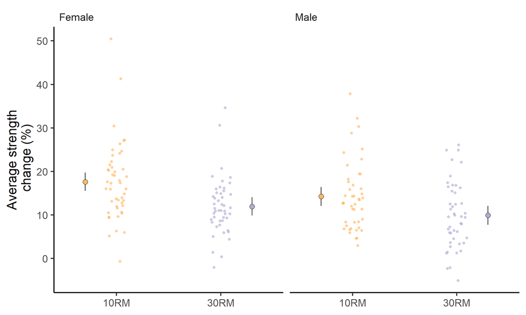

Figure 12: Females showed greater increases in average strength (%) (p = 0.045) with no differences between males and females across training conditions (p = 0.422) os baseline relative fat mass (p = 0.515)

Male gain in average strength was 12.1%, [10.2, 14] and in females 14.8%, [12.9, 16.7]. The average estimated difference between males and females was -2.8%-points, [-5.4, -0.1]. The average difference between conditions was -4.4%-point, [-6.5, -2.3] in male and -5.6%-point, [-7.6, -3.6] in females. The differences between sexes condition-differences was estimated to 1.2%-points, [-1.7, 4.1]. For every percentage-point increase in baseline fat mass, males were estimated to have a -0.3%-point, [-0.6, 0.1] and females -0.1%-point, [-0.4, 0.2] difference in average strength training induced change. Difference between sexes was estimated to -0.2%-points, [-0.6, 0.3].